### Resolve the missing data

- measure the severity
- fill in the missing values
- produce a full dataset with no NA’s
- display a histogram of the daily steps from the full dataset
- summarize the impact of altering the data

```r
#how many step measurements are NA?
data.na <- as.data.frame(subset(data, is.na(data$steps)))
nrow(data.na)
```

```
## [1] 2304
```

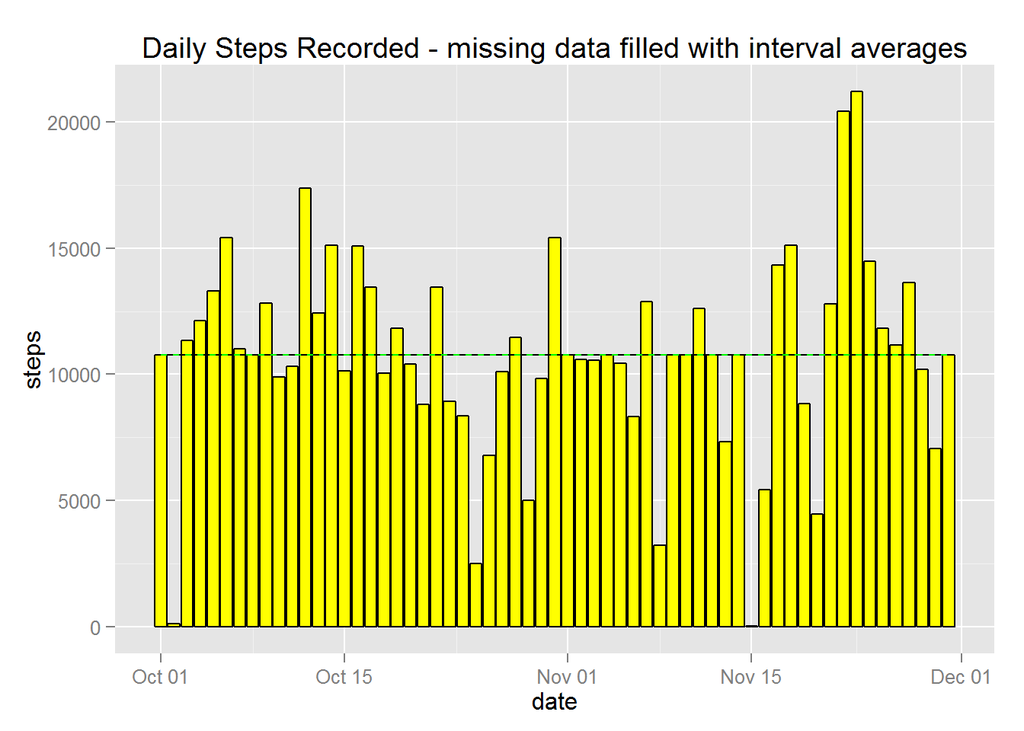

```r
#merge the na's with the average steps by interval
data.na <- merge(x = data.na, y = zsteps, by = "interval", all = TRUE)

#match the structure of the z data.frame
data.na <- as.data.frame(c(data.na[4], data.na[3], data.na[1]))
names(data.na) <- c("steps", "date", "interval")

#combine the data with no na's with the data with mean steps that replace na's
data.clean <- rbind(z, data.na)

#get the clean data daily step total, mean and median
csum <- aggregate(steps ~ date, data = data.clean, FUN="sum")
cmean <- mean(csum$steps)
cmed <- median(csum$steps)

#plot the histogram of the daily steps with values filled
c2 <- ggplot(csum, aes(x=date, y=steps)) + geom_histogram(stat="identity", fill="yellow", colour="black")
c2 <- c2 + geom_line(stat="hline", yintercept="mean")
c2 <- c2 + geom_line(stat="hline", yintercept="median", colour="green", linetype="dashed")
c2 <- c2 + ggtitle("Daily Steps Recorded - missing data filled with interval averages")
c2
```

```r
#what is the impact of replacing the NA's with the interval mean?
summary(zsum) #Data with NA's excluded
```

```
##       date                steps
##  Min.   :2012-10-02   Min.   :   41
##  1st Qu.:2012-10-16   1st Qu.: 8841
##  Median :2012-10-29   Median :10765
##  Mean   :2012-10-30   Mean   :10766
##  3rd Qu.:2012-11-16   3rd Qu.:13294
##  Max.   :2012-11-29   Max.   :21194
```

```r
summary(csum) #Data with NA's replaced
```

```
##       date                steps
##  Min.   :2012-10-01   Min.   :   41
##  1st Qu.:2012-10-16   1st Qu.: 9819
##  Median :2012-10-31   Median :10766
##  Mean   :2012-10-31   Mean   :10766
##  3rd Qu.:2012-11-15   3rd Qu.:12811
##  Max.   :2012-11-30   Max.   :21194
```

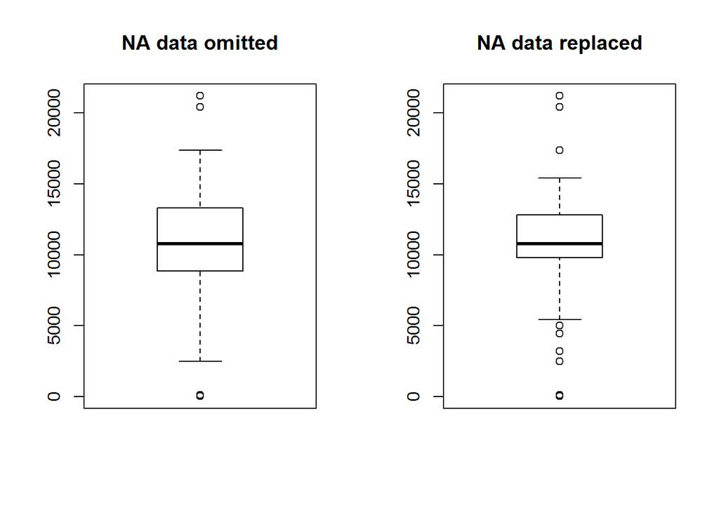

```r
par(mfrow=c(1,2))
boxplot(zsum$steps)
title("NA data omitted")
boxplot(csum$steps)
title("NA data replaced")
```

```r
#include to address knitr issue
par(mfrow=c(1,1))
```

### Compare weekends to weekdays

- use the data with NA steps replaced by interval mean
- mark the day as weekday or weekend
- average the interval steps by weekday or weekend
- display in a two panel time series plot

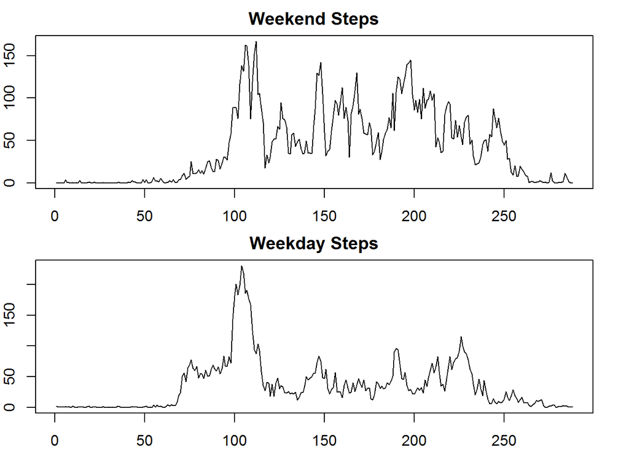

```r
#mark the date as weekend or weekday
data.clean$weekday <- as.factor(weekdays(data.clean$date))
data.clean$weekend <- rep("weekday", nrow(data.clean))
data.clean$weekend[data.clean$weekday == "Saturday"] <- "weekend"
data.clean$weekend[data.clean$weekday == "Sunday"] <- "weekend"
data.clean$weekend <- as.factor(data.clean$weekend)

#average the interval steps by weekday or weekend
wsteps <- aggregate(steps ~ interval + weekend, data = data.clean, FUN="mean")
weekendsteps <- subset(wsteps, wsteps$weekend == "weekend")
weekdaysteps <- subset(wsteps, wsteps$weekend != "weekend")

#2 row panel plot the output
par(mfrow=c(2,1), mar=c(2,2,2,2))
plot.ts(weekendsteps$steps)
title("Weekend Steps")
plot.ts(weekdaysteps$steps)
title("Weekday Steps")
```

```r
#include to address knitr issue
par(mfrow=c(1,1))
```